# Heart Rate Variability

We can use the RHRV pacakge to analyse heart rate variability.

```r
library(tidyverse)
library(RHRV)
library(data.table)
path_to_file = "~/Downloads/IBI.csv"
f = fread(path_to_file, header=F, sep = ",")%>%
  as.data.frame()
t0 = f[1,1]%>%
  as.POSIXct(origin = "1970-01-01", tz = "EST")
dat = f[2:nrow(f),1]%>%
  as.vector()
hd  = CreateHRVData()
hd = SetVerbose(hrv.data, TRUE )
hd = LoadBeatVector(hd, dat, datetime = format(t0,format = "%d/%m/%Y %H:%M:%S"))
```

```
 Loading beats positions
 Scale: 1
 Date: 05/05/2017
 Time: 02:24:58
 Number of beats: 5296
```

# Sanity Check Plot

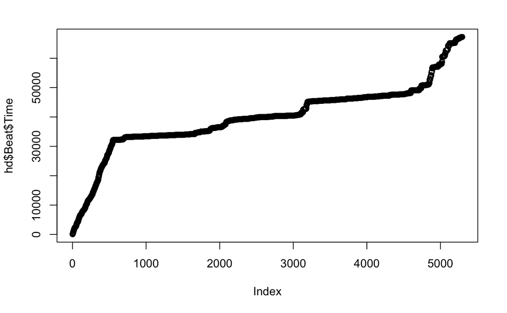

```r
plot(hd$Beat$Time)
```

According to the tutorials, this should be a straight line, however, the fact that it isn’t may indicate non-wear time. What do you think?

# Calculate and Plot the Heart Rate

```r
hd = BuildNIHR(hd)
```

```
 Calculating non-interpolated heart rate
 Number of beats: 5296
```

```
 Plotting non-interpolated instantaneous heart rate
 Number of points: 5296
```

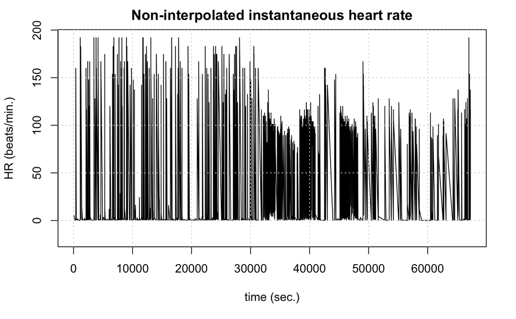

```r
PlotNIHR(hd)
```

A lot of messy data here. It should look something like this:

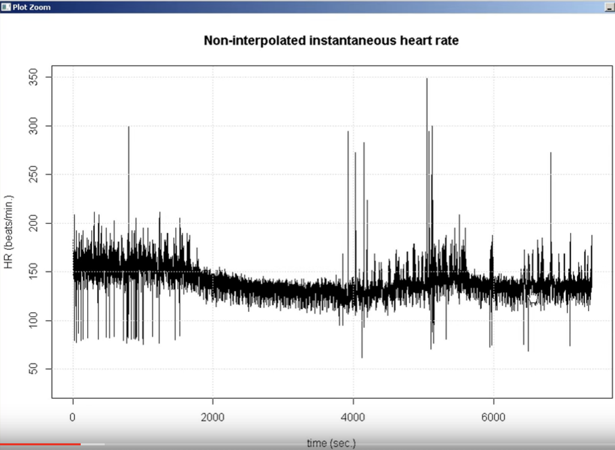

Screenshot from Tutorial

There are likely artifacts, which we can remove using RHRV:

# Filtering

```r
hd = FilterNIHR(hd)
```

```
 Filtering non-interpolated Heart Rate
 Number of original beats: 5296
 Number of accepted beats: 4144
```

We can see that the data has been reduced from the output, and the plot has changed:

```
 Plotting non-interpolated instantaneous heart rate
 Number of points: 4144
```

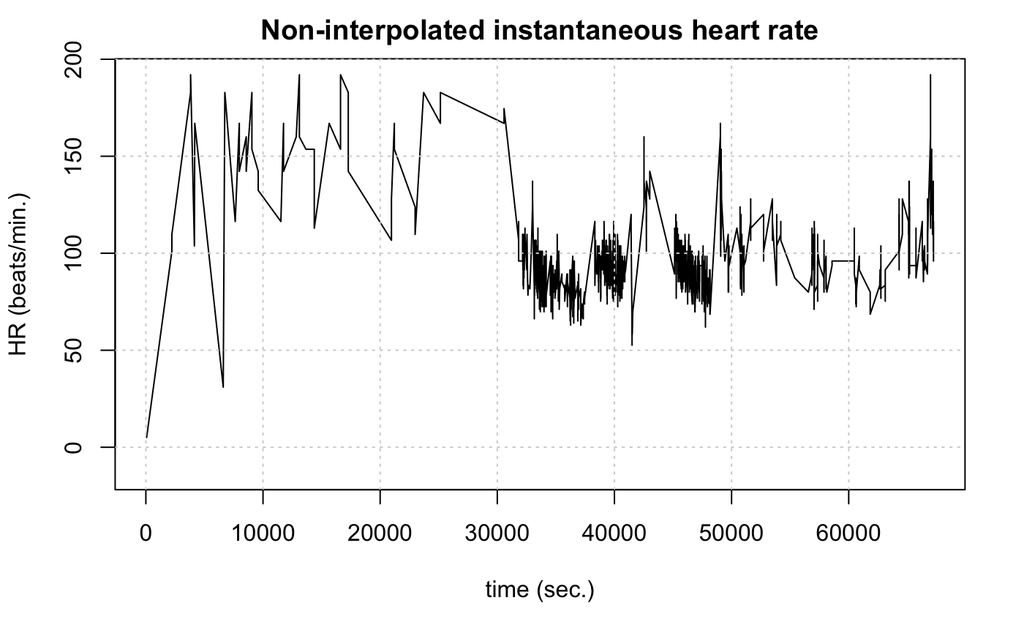

```r
PlotNIHR(hd)
```

I’m not particularly fond of the results. The developers suggest creating a back up and adjusting filter parameters.

```r
hd = FilterNIHR(hd, long = 50, last = 10, minbpm = 25, maxbpm = 180)
```

```
 Filtering non-interpolated Heart Rate
 Number of original beats: 4144
 Number of accepted beats: 4131
```

```
 Plotting non-interpolated instantaneous heart rate
 Number of points: 4131
```

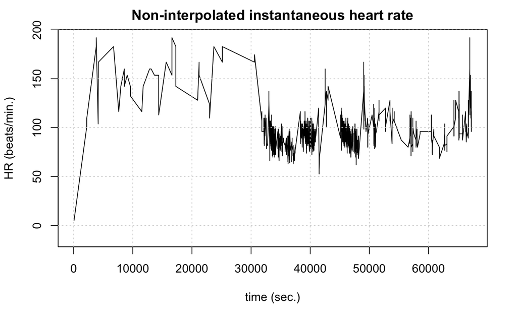

```r
PlotNIHR(hd)
```

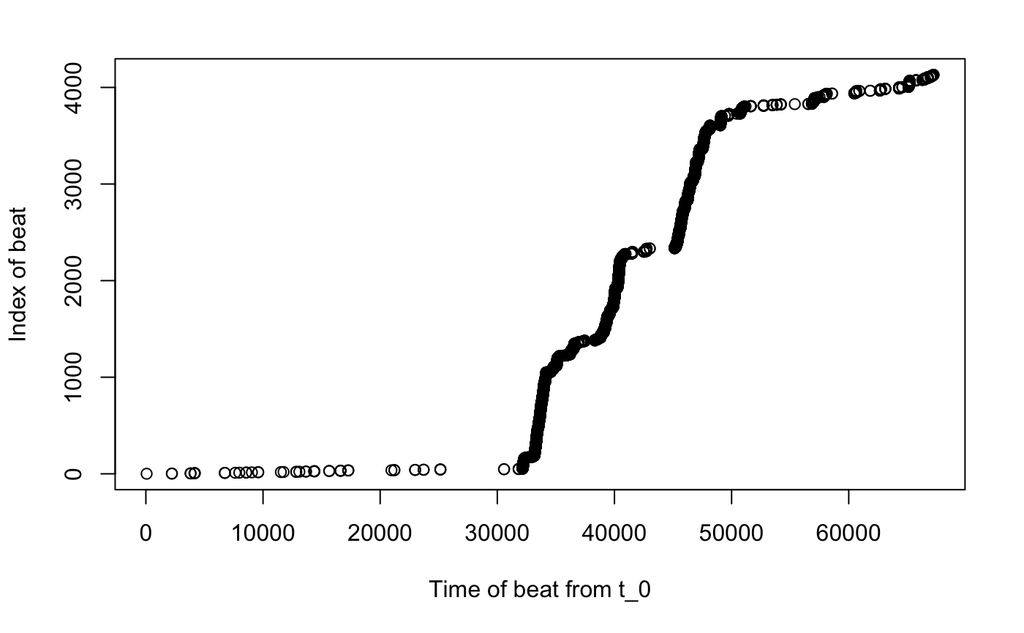

We may have to investigate different thresholds to make this more accurate and usable.

# Interpolation

So far, we’ve worked with non-interpolated heart rate monitoring. Now, we add interpolation (predicting values at unsmapled locations).

```r
hd = InterpolateNIHR(hd,4) #4hz interpolation is good for human recordings
```

[output not shown]

```
 Plotting interpolated instantaneous heart rate
 Number of points: 268695
```

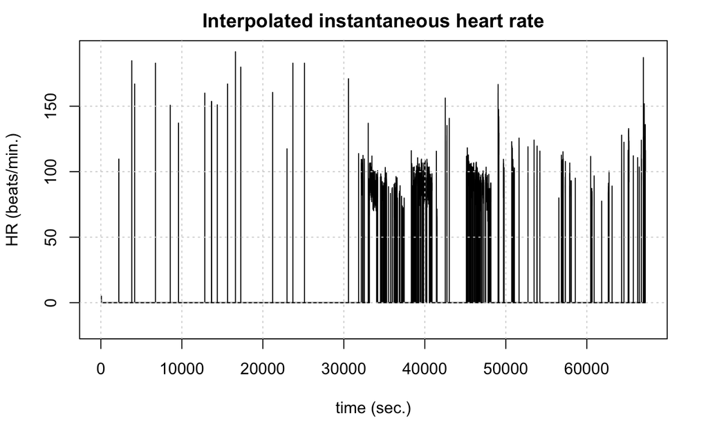

```r
PlotHR(hd)
```

Not pretty, but it could be the nature of the data set itself in this session. Will need to investigate parameters that will make for better filtering.

# Time Domain Analysis

This package makes time domain analysis possible very easily with literature standard output.

```r
hd = CreateTimeAnalysis(hd) #using default values
```

```
 Creating time analysis
 Size of window: 300 seconds
 Width of bins in histogram: 7.8125 milliseconds
Interval without beats from 365.081104 to 665.081104 seconds! Returning NA in SDANN and SDNNIDX Number of windows: 1
There is no window or just one window. Cannot compute the standard deviation! Returning NA in SDANN Data has now 1 time analyses
   SDNN: 193.0161 msec.
   SDANN: NA msec.
   SDNNIDX: NA msec.
   pNN50: 25.7143 %
   SDSD: 185.0469 msec.
   r-MSSD: 185.0446 msec.
   IRRR: 78.129 msec.
   MADRR: 31.252 msec.
   TINN: 147.7045 msec.
   HRV index: 9.4531
```

# Frequency Domain Analysis using Fourier Transform

Similarly, frequency domain analysis can be computed:

```r
hd = CalculatePowerBand(hd, size = 300, shift = 30)
```

```
 Calculating power per band
 Using Fourier analysis
 Windowing signal... 2230 windows
 Power per band calculated
```

```r
PlotPowerBand(hd, ymax = 2500, ymaxratio = 1.4)
```

[output not shown]

```
 Plotting power per band
```

The same can be completed using a Wavelet transform.